# new

2023-12-24

# Описательные статистики

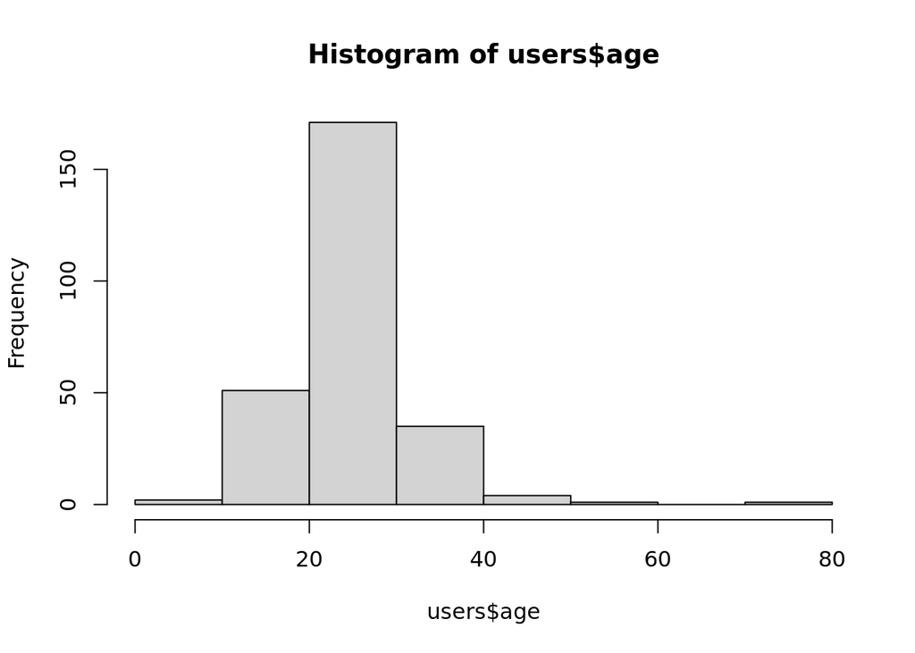

```
##             vars   n   mean    sd median trimmed    mad min max range  skew
## user_id*       1 300 150.50 86.75  150.5  150.50 111.19   1 300   299  0.00
## gender*        2 300   1.57  0.50    2.0    1.59   0.00   1   2     1 -0.30
## age            3 265  25.06  6.89   23.0   24.28   4.45   3  75    72  2.17
## country*       4 300  29.27 13.56   35.0   30.76  10.38   1  44    43 -0.65
## registered*    5 300 126.43 73.10  127.5  126.41  95.63   1 252   251  0.00
##             kurtosis   se
## user_id*       -1.21 5.01
## gender*        -1.92 0.03
## age            11.41 0.42
## country*       -1.06 0.78
## registered*    -1.24 4.22
```

Как мы видим, средний возраст слушателей составляет 25 лет и таких слушателей большинство, людей старше и младше меньше половины.

```
## country
##                            Argentina                              Armenia
##                                    4                                    1
##                            Australia                              Belgium
##                                    6                                    3
##                               Brazil       British Indian Ocean Territory
##                                    9                                    1
##                             Bulgaria                               Canada
##                                    1                                   14
##                                Chile                              Croatia
##                                    3                                    4
##                       Czech Republic                              Estonia
##                                    2                                    2
##                              Finland                               France
##                                   11                                    4
##                              Germany                               Greece
##                                    5                                    2
##                              Hungary                              Ireland
##                                    2                                    1
##                                Italy                                Japan
##                                   12                                    2
##                               Latvia                               Mexico
##                                    1                                    6
##                              Morocco                          Netherlands
##                                    1                                    4
##                          New Zealand                            Nicaragua
##                                    2                                    1
##                               Norway                                 Peru
##                                    9                                    1
##                               Poland                             Portugal
##                                   20                                    2
##                              Romania                   Russian Federation
##                                    3                                    4
##                               Serbia                             Slovakia
##                                    2                                    2
##                                Spain                               Sweden
##                                    7                                   10
##                          Switzerland                             Thailand
##                                    3                                    1
##                  Trinidad and Tobago                               Turkey
##                                    2                                   15
##                       United Kingdom                        United States
##                                   44                                   69
## United States Minor Outlying Islands                            Venezuela
##                                    1                                    1
```

Большинство пользователей из США и Великобритании. Многие из Польши.

```
##
##   f   m
## 128 172
```

Мужчин в выборке больше, чем женщин.

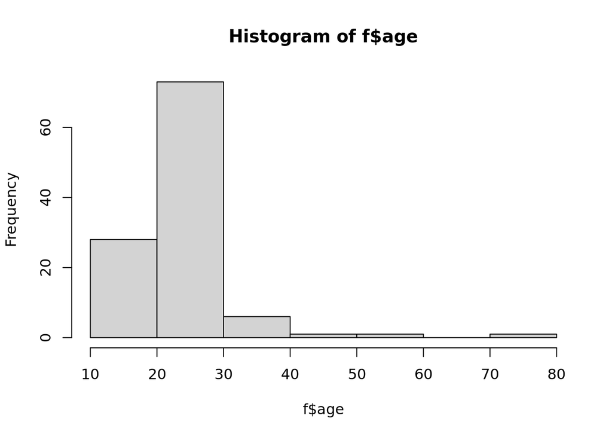

```
##    Min. 1st Qu.  Median    Mean 3rd Qu.    Max.    NA's
##   17.00   20.25   22.00   24.30   27.00   75.00      18
```

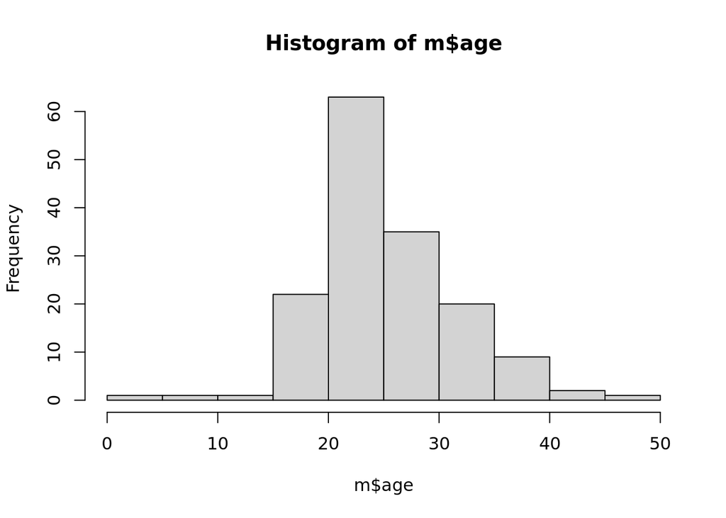

```
##    Min. 1st Qu.  Median    Mean 3rd Qu.    Max.    NA's
##    3.00   21.00   24.00   25.59   29.50   49.00      17
```

Мужчины в выборке в среднем старше, чем женщины.

Учитывая специфику распределения гендера и возвраста в этой выборке, я выдвину следующую гипотезу: H1 - женщины в этой выборке будут чаще мужчин слушать песни про любовь и подростковую музыку. Мужчины будут предпочитать другие жанры.

Чтобы проверить эту гипотезу и понять, какие жанры, выявленные на основе текстов песен, предпочитают слушать представители разных гендеров, я проанализирую лирику песен с помощью STM.

# Готовим данные

Количество уникальных песен в нашем датасете:

```
## [1] 17432
```

Количество уникальных сочетаний трек-исполнитель:

```
## [1] 19322
```

```
## [1] 19317 45853
```

```
## [1] 19317  4535
```

После очистки от самых частых и самых редких слов, их стало почти в 10 раз меньше: 4535.

# НУ, ПОЕХАЛИ. Строим STM модель

мне кажется, что популярная музыка 2007 года не очень разнообразна в темах текстов, так что начнем с 7 тем.

[output not shown]

Топ-10 популярных слов в каждой из тем:

```
## Topic 1 Top Words:
##       Highest Prob: time, life, world, mind, live, lose, change, hard, lie, run
##       FREX: i’m, time, change, anymore, wrong, don’t, mind, learn, forget, goodbye
##       Lift: canâ, didn’t, let’s, there’s, we’ll, what’s, who’s, you’ve, ain’t, anymore
##       Score: time, i’m, don’t, it’s, world, change, cry, life, mind, gonna
## Topic 2 Top Words:
##       Highest Prob: god, die, kill, soul, dead, blood, life, death, fear, hell
##       FREX: evil, human, flesh, suffer, holy, rage, sin, glory, demon, bleed
##       Lift: ancient, conquer, corruption, demise, existence, feast, grief, hell's, kingdom, prophecy
##       Score: death, blood, god, ov, kill, flesh, war, dead, pain, thy
## Topic 3 Top Words:
##       Highest Prob: la, fuck, shit, em, uh, yo, chorus, nigga, bitch, hit
##       FREX: la, shit, em, yo, nigga, bitch, ass, niggaz, y'all, huh
##       Lift: chasin, chef, coupe, fam, feds, g's, haters, homeboy, hustler, rappin
##       Score: la, nigga, yo, niggaz, shit, niggas, uh, y'all, bitch, em
## Topic 4 Top Words:
##       Highest Prob: feel, day, leave, fall, break, wait, walk, hear, home, head
##       FREX: wait, leave, strange, walk, break, fall, tire, inside, head, space
##       Lift: valentine, advertise, aeroplane, college, comfortable, depression, fond, mend, outer, queer
##       Score: fall, feel, break, inside, day, leave, head, home, stay, walk
## Topic 5 Top Words:
##       Highest Prob: night, eye, light, dream, sun, sky, rain, fly, blue, sing
##       FREX: sun, sky, moon, light, cloud, bright, wind, rain, sea, snow
##       Lift: gypsy, bright, dew, icy, meadow, misty, moonlight, rainbow, sail, sky
##       Score: sun, sky, light, rain, dream, shine, night, wind, moon, blue
## Topic 6 Top Words:
##       Highest Prob: dance, boy, gonna, play, lyric, rock, round, da, town, roll
##       FREX: dance, lyric, town, train, ba, chemical, band, mary, american, radio
##       Lift: gambler, holiday, jukebox, kong, robert, ruby, sheriff, shortcut, strummer, suburb
##       Score: lyric, da, dance, rock, chemical, roll, ba, town, gonna, party
## Topic 7 Top Words:
##       Highest Prob: love, baby, wanna, girl, hey, gonna, gotta, ooh, heart, feel
##       FREX: love, ooh, na, baby, babe, alright, whoa, hey, christmas, oo
##       Lift: feeling's, heartbreak, babe, christmas, darlin, heartache, liberate, love, na, oo
##       Score: love, baby, na, wanna, ooh, girl, hey, gonna, ah, gotta
```

Визуализируем:

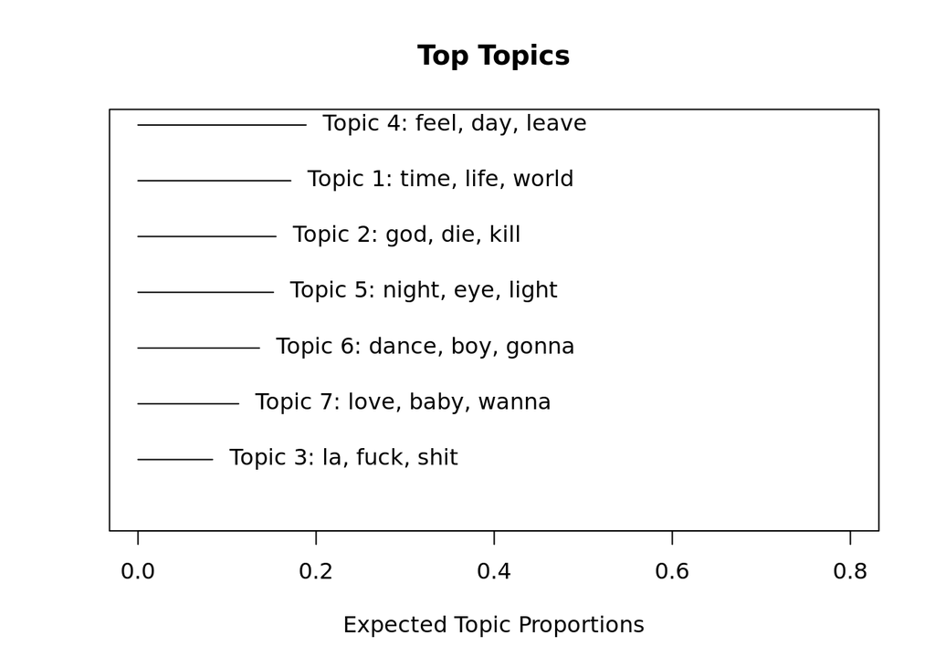

Посмотрим качество модели:

```
## [1]  -80.51573  -93.98826  -71.84100  -79.70988  -95.25164 -116.18297  -87.02791
## [1] 9.807988 9.021508 9.494676 9.858650 9.771408 9.321808 9.844350
```

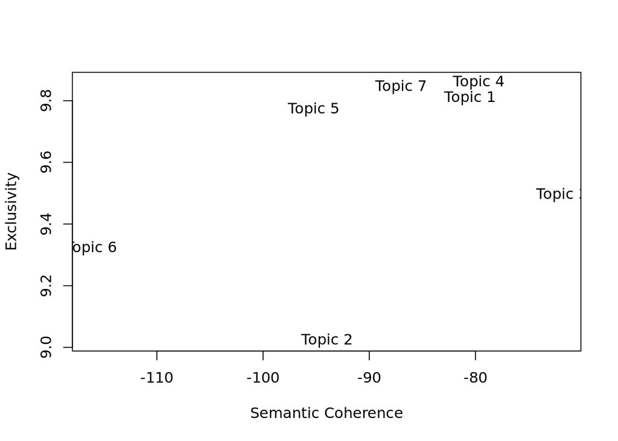

Как мы видим, значение exlusivity получилось высоким, а это значит, что выделенны жанры герметичны и мало пересекаются друг с другом. Как пишут здесь (https://bookdown.org/paul/computational_social_science/lab-structural-topic-model.html) - в правом углу собираются топики, где хороши оба показателя - а значит, модель на них сработала хорошо. Здесь плохо то, что exclusivity скачет и в этом плане топики 2 и 6 выделяются. Но несмотря на это содержательно очень нетурдно определить, чему посвящены песни из этого топика, в отличие от топиков 1 и 4.

# Интерпретация тем

В общем, количество выделенных топиков кажется оптимальным (я бы сделала k-means, но не успеваю). Мы можем назвать топики так: 1. Песни про расставание/депрессивная музыка - прощание, сожаление, изменения в жизни. 2. Суровый нефолк - войны, кровь, бог, демон, убийства 3. Рэп - много междометий и мата 4. Подростковая музыка - чувства, много глаголов, упоминаются college и depression 5. Музыка про природу - солнце, небо, облака, мечты. Наверное, жизнерадостная музыка. 6. Танцевальная музыка - танцевать, рок 7. Любовная музыка - любовь, малышка, чувства, тоже много междометий

# Проверка гипотезы

Теперь проверим гипотезы и посмотрим, какие группы людей чаще всего слушают какие песни.

Связь между возрастом и доли топика 1 в треке для мужчин и для женщин:

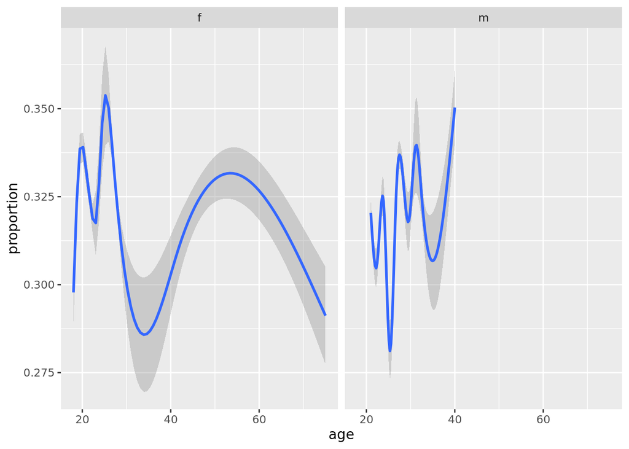

Значимых различий в предпочтениях для мужчин и женщин нет, и чаще всего такую музыку слушают молодые люди - но это, скорее всего, связано с несбалансированностью выборки по возрасту.

Связь между возрастом и доли топика 2 в треке для мужчин и для женщин:

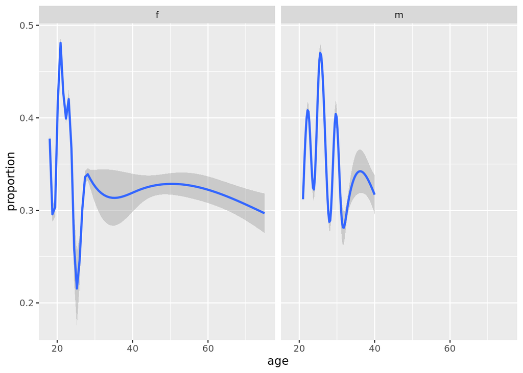

Здесь тоже нет никаких значимых различий, хотя жанр получился очень специфичный.

Связь между возрастом и доли топика 3 в треке для мужчин и для женщин:

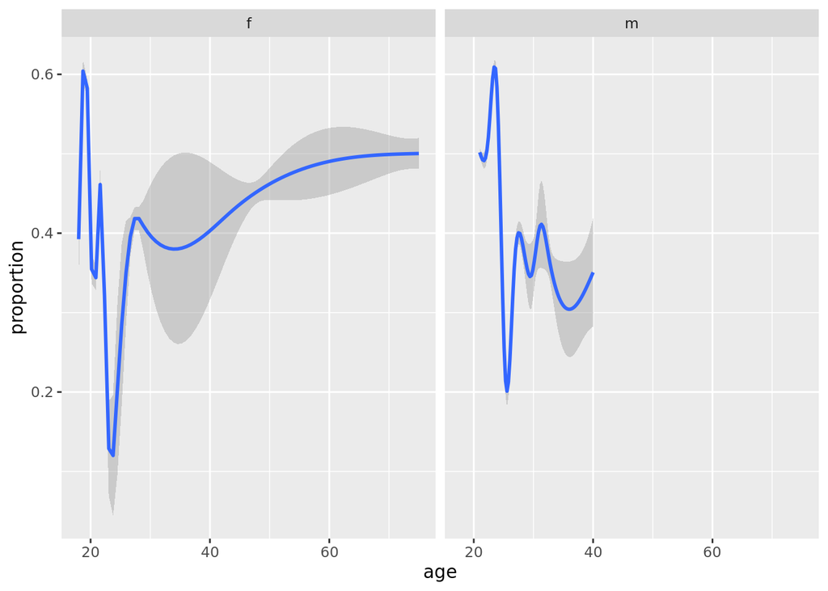

Здесь тоже нет значимых различий для гендеров, но возрастная динамика очень забавная: слушатели очень увлекаются репом в возрасте около 20 (мужчины чуть позже женщин), а потом интерес быстро угасает.

Связь между возрастом и доли топика 4 в треке для мужчин и для женщин:

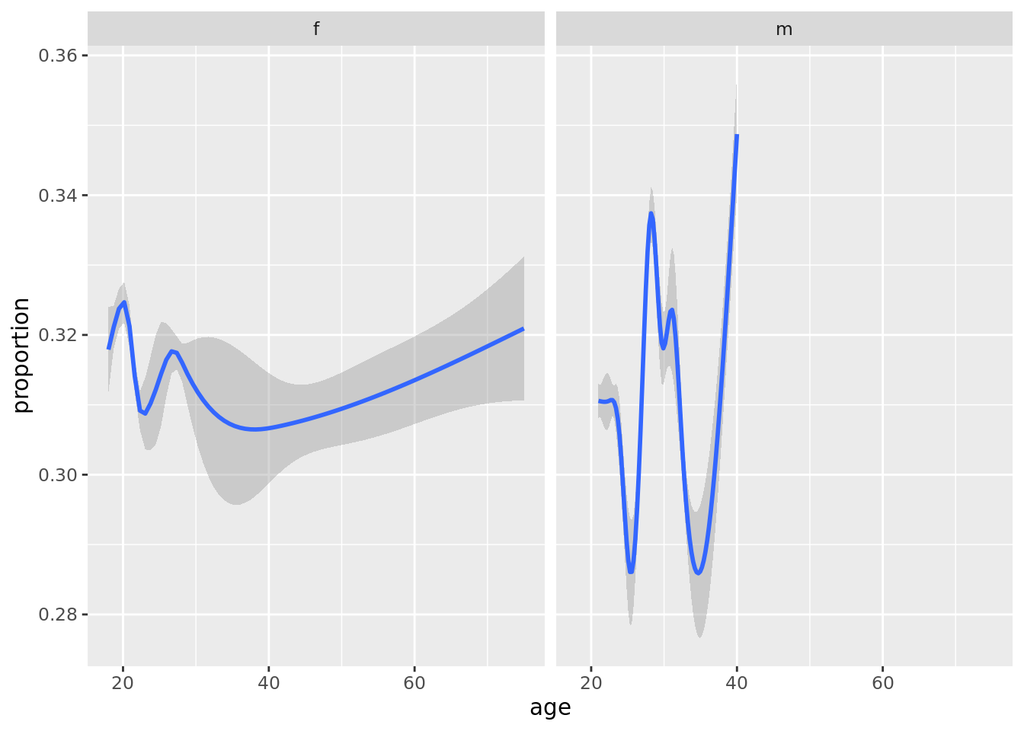

Ура! Наконец-то что-то новенькое, но с очень широкими доверительными интервалами, и поэтому не вызывающее доверие. Женщины стабильно средне интересуются тем, что я назвала подростковой и слегка депрессивной музыкой, А мужчины начинают очень интересоваться этой музыкой в возрасте около 30 лет. (или это все один человек, который прослушал трек подобного жанра несколько тысяч раз).

Связь между возрастом и доли топика 5 в треке для мужчин и для женщин:

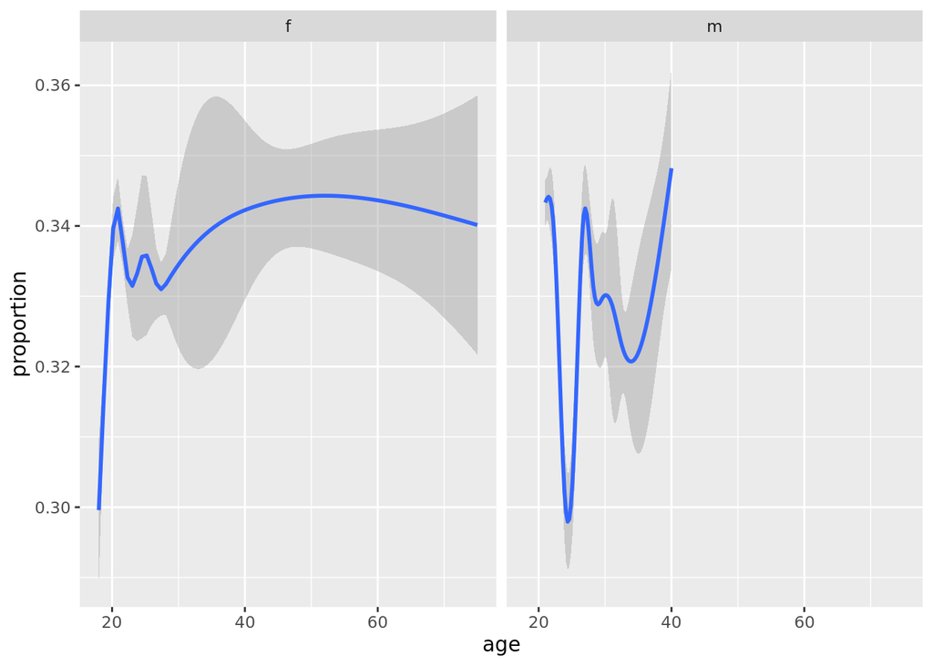

Связь между возрастом и доли топика 6 в треке для мужчин и для женщин:

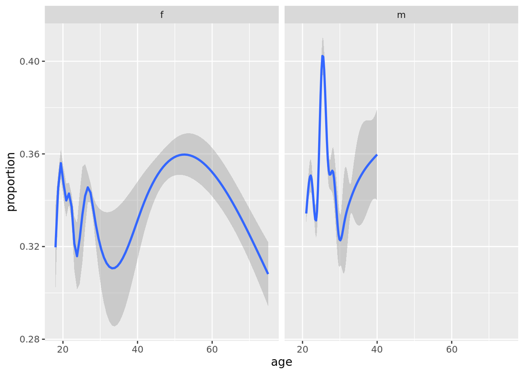

Мужчинам нравится танцевальная музыка больше чем женщинам, пик приходится на 25 лет.

Связь между возрастом и доли топика 7 в треке для мужчин и для женщин:

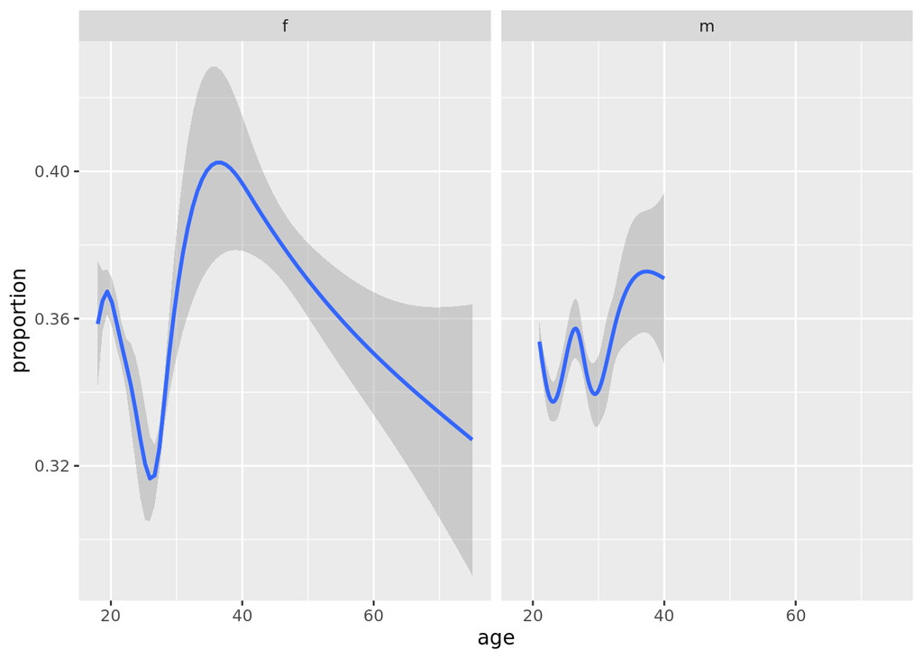

Жещины часто слушают любовную музыку около 20, после 20 интерес сильно падает и возрастает чуть выше уровня 20 лет после 30. Мужчины же слушают ее примерно с той же долей, что у девушек в 20 лет, примерно все время, а после 30 доля этой музыки тоже возрастает.

# Вывод

Действительно удалось увидеть какие-то гендерные предпочтения, но не совсем такие, как я ожидала. Я смотрела, как меняется доля одно или иного топика среди женщин и мужчин в разных возрастных группах в подгруппах, где этот топик уже составляет значительную долю (0.2). То есть, среди каких гендерно-возрастных групп тот или иной жанр выявленный на основе лирики треков получает максимальную популярность. Для этого я использовала графики с нелинейным трендом - самый простой, первичный визуальный тест. Какие-то значимые визуальные гендерные различия в музыкальных предпочтениях были только у части топиков:

топик 5: музыка про природу стабильно популярнее у женщин, у мужчин распространенность этого жанра скачет.

Топик 6: танцевальная музыка популярнее у мужчин. Особенно в 25

Топик 7: Мужчины и женщины слушают любовную музыку примерно одинаково часто, но женщины после 30 чаще всех.